# Lab 1 Forecasting with ARIMA and ETS models

### Step 6, forecast

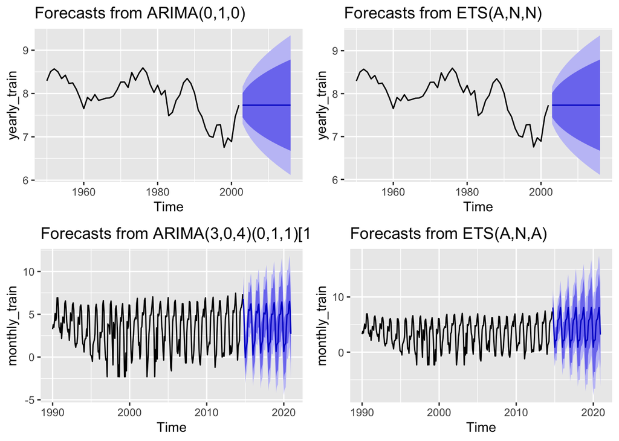

```r
# Generate forecasts for the test period
yearly_arima_forecast <- forecast(yearly_arima, h = length(yearly_test))
yearly_ets_forecast <- forecast(yearly_ets, h = length(yearly_test))

monthly_arima_forecast <- forecast(monthly_arima, h = length(monthly_test))
monthly_ets_forecast <- forecast(monthly_ets, h = length(monthly_test))

# Plot forecasts
plot1<-autoplot(yearly_arima_forecast)
plot2<-autoplot(yearly_ets_forecast)

plot3<-autoplot(monthly_arima_forecast)
plot4<-autoplot(monthly_ets_forecast)

# Put into a 4 plot panel
library(gridExtra)
library(grid)
library(ggplot2)

grid.arrange(plot1, plot2, plot3, plot4, ncol = 2)
```

## Accuracy metrics

```r
# Evaluate forecast accuracy
yearly_arima_accuracy <- accuracy(yearly_arima_forecast, yearly_test)

#                     ME      RMSE       MAE        MPE     MAPE      MASE      ACF1 Theil's U
# Training set -0.01046748 0.2175570 0.1732156 -0.1712576 2.225795 0.9820193 0.0292464        NA
# Test set     -0.07686666 0.2753066 0.2363580 -1.1236585 3.107135 1.3399954 0.5697271  1.139735

yearly_ets_accuracy <- accuracy(yearly_ets_forecast, yearly_test)

#                     ME      RMSE       MAE        MPE     MAPE      MASE       ACF1
# Training set -0.01062423 0.2175548 0.1730609 -0.1731526 2.223930 0.9811418 0.02860653
# Test set     -0.07683952 0.2752990 0.2363503 -1.1233035 3.107024 1.3399514 0.56972710

monthly_arima_accuracy <- accuracy(monthly_arima_forecast, monthly_test)

#                     ME     RMSE       MAE  MPE MAPE      MASE         ACF1 Theil's U
# Training set -0.0620450 1.314323 0.9435214 -Inf  Inf 0.8521606 -0.001970859        NA
# Test set     -0.9640865 3.266402 2.5277314 -Inf  Inf 2.2829721  0.737652808         0

monthly_ets_accuracy <- accuracy(monthly_ets_forecast, monthly_test)

#                       ME     RMSE      MAE  MPE MAPE     MASE      ACF1 Theil's U
# Training set  0.0008512003 1.653080 1.088517 -Inf  Inf 0.983116 0.3694314        NA
# Test set     -1.8938374286 3.914736 2.998623 -Inf  Inf 2.708267 0.7424152         0
```

## Results and Discussion

The accuracy metrics show that for yearly data, ARIMA and ETS models performed nearly the same with a MAPE value of about 3.1%, indicating reasonably accurate forecasts. For the monthly data, the ARIMA model outperformed ETS with lower RMSE (3.27 vs 3.91) and MAE (2.53 vs 3.00)

Visually, the plots suggest better monthly performance but the numerical metrics indicate higher absolute errors for monthly forecasts compared to yearly ones. It would be interesting to compare how each of these predictions preform on test data from the other dataset (i.e. do predictions made from monthly data preform better for yearly data). Similarly, it would be interesting to compare the results here to that of the data from California, which is made complicated by the different range of time series values. We questioned the legitimacy of our methods for fitting an ARIMA to the yearly data, as the model suggests that the predicted catch for the next years is equal to the last year’s catch. This held true with some back-of-the envelope calculations using the same methods on the California and Oregon data. Specifically, we question the fact that the forecast plot visually shows no variation that would typically be associated with a random walk, rather forecasting a straight line with no variation.

##Team Member Contributions

BM, EC, and TT all contributed code, question design, and analysis to the final work presented here. EC wrote details about the initial plan and questions we addressed, and how the plan was carried out, as well as added details to the discussion section. TT added details about checking the residuals and the ACF/PACF plots, and wrote details about the results and discussion. BM wrote and organized final code and added details about Accuracy results.